# Cobertura del emparejamiento evento-elemento y delimitacion del dataset de modelado

Edwin Silva Salas

2026-06-15

# Etapa 3 — Emparejamiento evento–elemento (complemento Sección 5.3.5)

Al contrastar los totales anuales de eventos en `tabla_eventos_ajustado.csv` (BRAE) con la suma de `n_eventos` en `data_agrupada.csv` (cuadrante × semana), se evidencia un **subregistro sistemático** en el grano espacial durante 2021–2023. La causa técnica no es la ausencia del campo `COMPONENTE_FALLADO` en BRAE —que está completo en todos los años—, sino la **incompatibilidad de codificación** entre el identificador registrado en el evento y el inventario georreferenciado `tipo_elemento.csv` (Tabla 5.5, paso 5.2.1.4).

En la compañía coexisten **dos esquemas de codificación** para los activos de red:

1. **Código de sitio (ubicación):** identifica de forma estable el punto de conexión en el territorio.
2. **Código de activo:** identifica el equipo instalado; **cambia cuando el activo se repone** por mantenimiento o renovación, mientras el código de sitio permanece.

El panel consolidado y el inventario GIS emplean el código de **sitio** (`ELEMENTO` en `tipo_elemento.csv`). En cambio, OMS-SPARD registraba con frecuencia el **código del activo** reemplazado en el campo de elemento fallado (`BREAKER` $\rightarrow$ `COMPONENTE_FALLADO`), lo que impide el cruce histórico evento $\rightarrow$ punto de desconexión $\rightarrow$ cuadrante: clave para el análisis espacial de esta tesis. OMS-SP7 homogeniza parcialmente la práctica, lo que explica la mayor cobertura en 2024–2025 sin alcanzar el 100~%.

Este informe cuantifica la brecha anual y define el subconjunto analítico $D_{\mathrm{mod}}$ para la Etapa~4.

```r
library(tidyverse)
library(lubridate)
library(scales)
library(knitr)
env_path <- file.path("..", "..", ".env")
if (file.exists(".env")) {
  readRenviron(".env")
} else if (file.exists(env_path)) {
  readRenviron(env_path)
}

UBICACION_DATA <- Sys.getenv("UBICACION_DATA")
if (UBICACION_DATA == "") {
  stop("UBICACION_DATA no esta definida. Verifica el archivo .env.")
}

path_eventos <- file.path(UBICACION_DATA, "tabla_eventos_ajustado.csv")
path_agrupada <- file.path(UBICACION_DATA, "data_agrupada.csv")
path_img_tesis <- file.path("..", "my-paper-overleaf", "img")

if (!file.exists(path_eventos)) stop("No se encontro: ", path_eventos)
if (!file.exists(path_agrupada)) stop("No se encontro: ", path_agrupada)
```

```r
guardar_plot <- function(plot, archivo, width, height) {
  ggsave(
    file.path(UBICACION_DATA, archivo),
    plot = plot,
    width = width,
    height = height,
    dpi = 300,
    bg = "white"
  )
  if (dir.exists(path_img_tesis)) {
    file.copy(
      file.path(UBICACION_DATA, archivo),
      file.path(path_img_tesis, archivo),
      overwrite = TRUE
    )
  }
}
```

## Eventos BRAE por año

```r
tabla_eventos <- read_csv(path_eventos, show_col_types = FALSE)

col_elemento <- if ("COMPONENTE_FALLADO" %in% names(tabla_eventos)) {
  "COMPONENTE_FALLADO"
} else if ("ELEMENTO_FALLADO" %in% names(tabla_eventos)) {
  "ELEMENTO_FALLADO"
} else {
  stop("No se encontro columna de elemento fallado en tabla_eventos_ajustado.csv")
}

tabla_eventos <- tabla_eventos %>%
  mutate(
    FECHA_DESCONEXION = dmy_hm(FECHA_DESCONEXION),
    anio = year(FECHA_DESCONEXION),
    tiene_elemento = !is.na(.data[[col_elemento]]) & .data[[col_elemento]] != ""
  )

eventos_brae_anio <- tabla_eventos %>%
  group_by(anio) %>%
  summarise(
    n_eventos_brae = n(),
    n_con_elemento = sum(tiene_elemento),
    pct_con_elemento = round(100 * n_con_elemento / n_eventos_brae, 1),
    .groups = "drop"
  ) %>%
  arrange(anio)

eventos_brae_anio
```

```
## # A tibble: 5 × 4
##    anio n_eventos_brae n_con_elemento pct_con_elemento
##   <dbl>          <int>          <int>            <dbl>
## 1  2021          18398          18398              100
## 2  2022          17542          17542              100
## 3  2023          20068          20068              100
## 4  2024          19583          19583              100
## 5  2025          19689          19689              100
```

## Coincidencia con el inventario GIS (`tipo_elemento.csv`)

El panel activo $\times$ día se construye a partir de `tipo_elemento.csv` (Tabla 5.5), cuyo campo `ELEMENTO` corresponde al **código de sitio** georreferenciado. Se evalúa, por año, en qué proporción el `COMPONENTE_FALLADO` del evento coincide con algún `ELEMENTO` del inventario; los eventos sin coincidencia no pueden propagarse a `FRECUENCIA` ni a `data_agrupada`.

```r
path_inventario <- file.path(UBICACION_DATA, "tipo_elemento.csv")
if (!file.exists(path_inventario)) {
  stop("No se encontro: ", path_inventario)
}

tipo_elemento <- read_csv(path_inventario, show_col_types = FALSE)
inventario_elementos <- unique(tipo_elemento$ELEMENTO)

tabla_eventos <- tabla_eventos %>%
  mutate(
    en_inventario_gis = .data[[col_elemento]] %in% inventario_elementos
  )

match_inventario_anio <- tabla_eventos %>%
  group_by(anio) %>%
  summarise(
    n_en_inventario = sum(en_inventario_gis),
    pct_en_inventario = round(100 * mean(en_inventario_gis), 1),
    .groups = "drop"
  )

match_inventario_anio
```

```
## # A tibble: 5 × 3
##    anio n_en_inventario pct_en_inventario
##   <dbl>           <int>             <dbl>
## 1  2021            5617              30.5
## 2  2022            5416              30.9
## 3  2023            6371              31.7
## 4  2024           15622              79.8
## 5  2025           18700              95
```

```r
n_distinct(tipo_elemento$ELEMENTO)
```

```
## [1] 47649
```

## Eventos en tabla agrupada por año

```r
tabla_agrupada <- read_csv(path_agrupada, show_col_types = FALSE)

if ("semana" %in% names(tabla_agrupada) &&
    !inherits(tabla_agrupada$semana, "Date")) {
  tabla_agrupada <- tabla_agrupada %>%
    mutate(semana = as.Date(semana))
}

eventos_agrupada_anio <- tabla_agrupada %>%
  mutate(anio = year(semana)) %>%
  group_by(anio) %>%
  summarise(
    n_eventos_agrupada = sum(n_eventos, na.rm = TRUE),
    n_filas = n(),
    n_semanas = n_distinct(semana),
    cuadrantes_con_evento = sum(n_eventos > 0, na.rm = TRUE),
    .groups = "drop"
  ) %>%
  arrange(anio)

eventos_agrupada_anio
```

```
## # A tibble: 6 × 5
##    anio n_eventos_agrupada n_filas n_semanas cuadrantes_con_evento
##   <dbl>              <dbl>   <int>     <int>                 <int>
## 1  2020                 26     344         1                    19
## 2  2021               5167   17888        52                  3005
## 3  2022               4934   17888        52                  2946
## 4  2023               5845   17888        52                  3338
## 5  2024              15211   18232        53                  6233
## 6  2025              18199   17888        52                  7118
```

## Tabla comparativa de cobertura

Columnas publicadas en la tesis: **Eventos BRAE**, **En inventario GIS** (% de `COMPONENTE_FALLADO` presente en `tipo_elemento.csv`), **Panel espacial** y **Cobertura (%)** respecto a BRAE.

```r
tabla_cobertura <- eventos_brae_anio %>%
  left_join(match_inventario_anio, by = "anio") %>%
  left_join(eventos_agrupada_anio, by = "anio") %>%
  mutate(
    pct_cobertura = round(100 * n_eventos_agrupada / n_eventos_brae, 1)
  ) %>%
  select(
    anio,
    n_eventos_brae,
    n_con_elemento,
    pct_con_elemento,
    n_en_inventario,
    pct_en_inventario,
    n_eventos_agrupada,
    pct_cobertura
  )

tabla_cobertura
```

```
## # A tibble: 5 × 8
##    anio n_eventos_brae n_con_elemento pct_con_elemento n_en_inventario
##   <dbl>          <int>          <int>            <dbl>           <int>
## 1  2021          18398          18398              100            5617
## 2  2022          17542          17542              100            5416
## 3  2023          20068          20068              100            6371
## 4  2024          19583          19583              100           15622
## 5  2025          19689          19689              100           18700
## # ℹ 3 more variables: pct_en_inventario <dbl>, n_eventos_agrupada <dbl>,
## #   pct_cobertura <dbl>
```

```r
tabla_cobertura_publica <- tabla_cobertura %>%
  select(
    anio,
    n_eventos_brae,
    pct_en_inventario,
    panel_espacial = n_eventos_agrupada,
    pct_cobertura
  )

write_csv(
  tabla_cobertura,
  file.path(UBICACION_DATA, "cobertura_emparejamiento_por_anio.csv")
)

kable(
  tabla_cobertura_publica,
  col.names = c(
    "Anio",
    "Eventos BRAE",
    "En inventario GIS (%)",
    "Panel espacial",
    "Cobertura panel (%)"
  ),
  format = "html",
  digits = 1
)
```

| Anio | Eventos BRAE | En inventario GIS (%) | Panel espacial | Cobertura panel (%) |
| --- | --- | --- | --- | --- |
| 2021 | 18398 | 30.5 | 5167 | 28.1 |
| 2022 | 17542 | 30.9 | 4934 | 28.1 |
| 2023 | 20068 | 31.7 | 5845 | 29.1 |
| 2024 | 19583 | 79.8 | 15211 | 77.7 |
| 2025 | 19689 | 95.0 | 18199 | 92.4 |

## Gráfico comparativo BRAE vs agrupada

Solo se contrastan los dos conteos que aportan información distinta: el registro transaccional BRAE y los eventos que efectivamente llegan al panel espacial (`data_agrupada`). La serie ``con elemento asignado’’ coincide con BRAE al 100~% y se omite del gráfico para evitar redundancia visual.

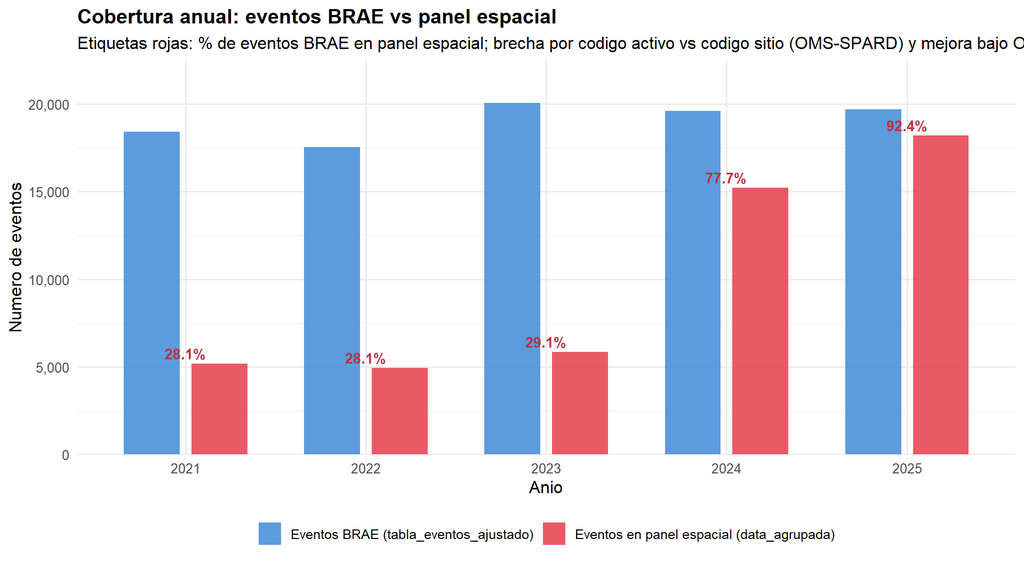

```r
datos_grafico <- tabla_cobertura %>%
  select(anio, n_eventos_brae, n_eventos_agrupada, pct_cobertura) %>%
  pivot_longer(
    cols = c(n_eventos_brae, n_eventos_agrupada),
    names_to = "fuente",
    values_to = "n_eventos"
  ) %>%
  mutate(
    fuente = factor(
      fuente,
      levels = c("n_eventos_brae", "n_eventos_agrupada"),
      labels = c(
        "Eventos BRAE (tabla_eventos_ajustado)",
        "Eventos en panel espacial (data_agrupada)"
      )
    )
  )

etiquetas_pct <- tabla_cobertura %>%
  transmute(
    anio,
    fuente = factor(
      "Eventos en panel espacial (data_agrupada)",
      levels = levels(datos_grafico$fuente)
    ),
    n_eventos = n_eventos_agrupada,
    etiqueta = paste0(pct_cobertura, "%")
  )

grafico_cobertura <- ggplot(datos_grafico, aes(x = factor(anio), y = n_eventos, fill = fuente)) +
  geom_col(position = position_dodge(width = 0.75), width = 0.62, alpha = 0.9) +
  geom_text(
    data = etiquetas_pct,
    aes(x = factor(anio), y = n_eventos, label = etiqueta),
    position = position_dodge(width = 0.75),
    inherit.aes = FALSE,
    vjust = -0.45,
    fontface = "bold",
    size = 3.6,
    color = "#B8323D"
  ) +
  scale_y_continuous(labels = comma, expand = expansion(mult = c(0, 0.12))) +
  scale_fill_manual(values = c("#4A90D9", "#E84855")) +
  labs(
    title = "Cobertura anual: eventos BRAE vs panel espacial",
    subtitle = paste(
      "Etiquetas rojas: % de eventos BRAE en panel espacial;",
      "brecha por codigo activo vs codigo sitio (OMS-SPARD) y mejora bajo OMS-SP7"
    ),
    x = "Anio",
    y = "Numero de eventos",
    fill = NULL
  ) +
  theme_minimal(base_size = 12) +
  theme(
    plot.title = element_text(face = "bold"),
    legend.position = "bottom",
    legend.text = element_text(size = 9.5)
  )

grafico_cobertura
```

```r
guardar_plot(
  grafico_cobertura,
  "cobertura_emparejamiento_por_anio.png",
  10,
  5.5
)
```

```
## [1] TRUE
```

## Definición del dataset de modelado ($D_{\mathrm{mod}}$)

Subconjunto de `data_agrupada.csv` restringido a **2024–2025**, periodo con mayor homogeneidad en la codificación bajo OMS-SP7 y cobertura del panel espacial del 77,7~% al 92,4~% frente a BRAE (vs. $\approx 28$–$29$~% en 2021–2023 bajo OMS-SPARD).

```r
d_mod <- tabla_agrupada %>%
  filter(year(semana) %in% 2024:2025)

resumen_d_mod <- tibble(
  metrica = c(
    "Filas (cuadrante x semana)",
    "Semanas distintas",
    "Cuadrantes distintos",
    "Total n_eventos",
    "Total usuarios_afectados",
    "Total duracion_total (horas)",
    "Rango semanas (inicio)",
    "Rango semanas (fin)"
  ),
  valor = c(
    as.character(nrow(d_mod)),
    as.character(n_distinct(d_mod$semana)),
    as.character(n_distinct(d_mod$id_cuadrante)),
    format(sum(d_mod$n_eventos, na.rm = TRUE), big.mark = ","),
    format(sum(d_mod$usuarios_afectados, na.rm = TRUE), big.mark = ","),
    format(round(sum(d_mod$duracion_total, na.rm = TRUE), 1), big.mark = ","),
    as.character(min(d_mod$semana)),
    as.character(max(d_mod$semana))
  )
)

resumen_d_mod
```

```
## # A tibble: 8 × 2
##   metrica                      valor
##   <chr>                        <chr>
## 1 Filas (cuadrante x semana)   36120
## 2 Semanas distintas            105
## 3 Cuadrantes distintos         344
## 4 Total n_eventos              33,410
## 5 Total usuarios_afectados     6,053,965
## 6 Total duracion_total (horas) 986,626.1
## 7 Rango semanas (inicio)       2024-01-01
## 8 Rango semanas (fin)          2025-12-29
```

```r
d_mod_anio <- d_mod %>%
  mutate(anio = year(semana)) %>%
  group_by(anio) %>%
  summarise(
    n_filas = n(),
    n_eventos = sum(n_eventos, na.rm = TRUE),
    eventos_por_semana = round(n_eventos / n_distinct(semana), 1),
    .groups = "drop"
  )

d_mod_anio
```

```
## # A tibble: 2 × 4
##    anio n_filas n_eventos eventos_por_semana
##   <dbl>   <int>     <dbl>              <dbl>
## 1  2024   18232     15211                287
## 2  2025   17888     18199                350
```

```r
write_csv(d_mod_anio, file.path(UBICACION_DATA, "resumen_d_mod_por_anio.csv"))
```

## Decisión para la Etapa 4

- **$D_{\mathrm{EDA}}$:** horizonte exploratorio 2021–2025 (Secciones 5.3.1–5.3.5).
- **$D_{\mathrm{mod}}$:** `data_agrupada.csv` filtrada a `year(semana) \in \{2024, 2025\}`.
- **Causa raíz de la brecha:** `COMPONENTE_FALLADO` (código de activo en OMS-SPARD) no siempre coincide con `ELEMENTO` de `tipo_elemento.csv` (código de sitio del inventario GIS).
- **Partición temporal propuesta:** entrenamiento con observaciones de **2024**; prueba con **2025** (validación forward en serie autocorrelacionada).

Los años 2021–2023 se conservan en el EDA pero **no** se emplean para estimar el modelo predictivo, dado el sesgo por incompatibilidad de codificación en el periodo OMS-SPARD.